# Model Fitting for mtcars Dataset

Mariusz Musiał

Dec. 27th 2015

# Introduction

The present report is focused on analysis of the mtcars dataset with the aim to provide answers to two questions:

1. Is an automatic or manual transmission better for MPG
2. Quantify the MPG difference between automatic and manual transmissions

By “better” in question 1 it is understood “higner” in terms of numerical value of MPG (miles per gallon).

The main part of the report contains only text and tables, whereas the supporting figures are available in the Appendix. Links to appropriate figures are included in the main text for easier navigation. The original Rmd file used to generate this report is available in my github repository [1]. The approach to variable transformations in this report was inspired by the “Building Multiple Regression Models Interactively” paper by Henderson and Velleman [2].

# Dataset Exploration

The **Motor Trend Car Dataset** (called `mtcars` from now on) consists of **32** observations (corresponding to car models) of **11** variables. The observed variables are:

```
##  [1] "mpg"  "cyl"  "disp" "hp"   "drat" "wt"   "qsec" "vs"   "am"   "gear"
## [11] "carb"
```

It is assumed that the reader is able to get the detailes description of each variable by using R help system (`?mtcars`).

Useful summary of the data for our purposes is presented in Figure 1. From this figure we see (upper panel) that the variables in the `mtcars` dataset can be divided into two groups:

- continuous variables (`hp`, `wt`, `disp`, `drat`, `qsec` and `mpg`)
- discrete variables (`carb`, `cyl`, `am`, `gear` and `vs`)

For better interpretability of the results, we’ll center and scale the continuous variables by substracting their respective means and dividing by standard deviations.

The lower panel of Figure 1 depicts the correlation ellipses and smooth lines for the pairwise variable relations. For the purpose of the present report we are primarily interested in relation of `mpg` with the remaining variables. The presented ellipse plots indicate that `mpg` is particularly strongly inversly correlated with `wt` (r = -0.8677), `cyl` (r = -0.8522), `disp` (r = -0.8476) and `hp` (r = -0.7762). There is also quite strong positive correlation between each pair of those 4 variables, what indicates that they are not mutually independent (what is quite logical as `hp`, `cyl` and `disp` should somehow be the result of the design decisions to achieve certain performance figures for a car with the resulting weight `wt`). These observations would need to be taken into account to avoid effects of multicollinearity when fitting the models.

Looking at the smooth lines on Figure 1 it can be seen that there is mostly non-linear relationship between `mpg` and the other variables, especially those strongly inversly correlated. As noted in [2], this suggests that for fitting a linear model with `mpg` as the dependent variable it would be better to fit to its inverse, `gpm` or gallon per mile.

# References

1. https://github.com/marioem/Regression-Models-Project.git
2. Harold V. Henderson, Paul F. Velleman (1981). *Building Multiple Regression Models Interactively*. Biometrics, Vol. 37, No. 2. (Jun., 1981), pp. 391-411.

# Appendix

## Figures

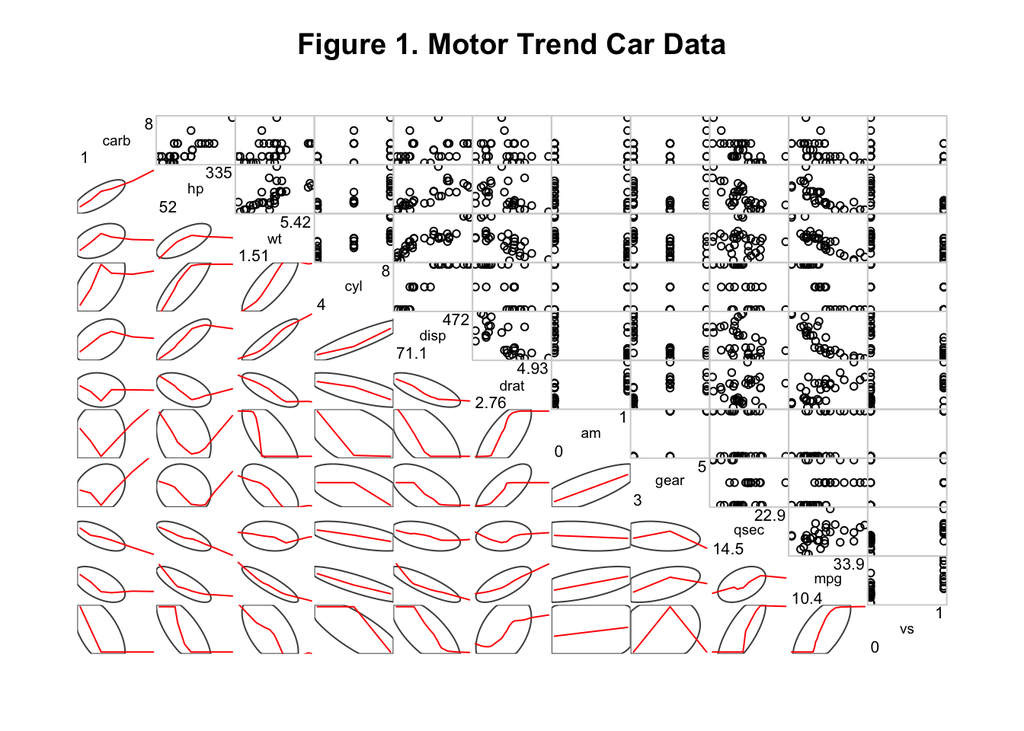

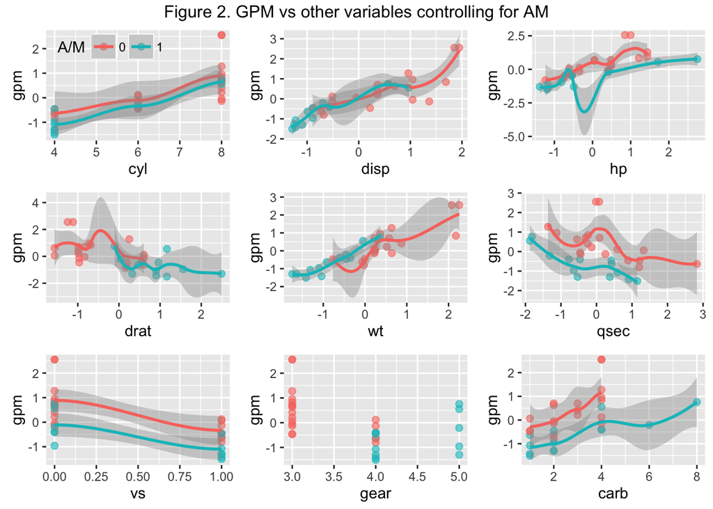